# Evaluation using resampling methods

Hector Corrada Bravo  
CADi 2015

### Evaluation

- So far we have discussed training set error
- But in first lecture on modeling we said we wanted to build models that **generalize** and don't **overfit**
- How do we measure that, when we we only have training data?

### Cross Validation

- Most common tool to evaluate model performance.
- Used in two essential modeling steps:
  - *Model Selection*: for a given model, what should be included?
  - *Model Assessment*: how well does our selected model perform?

### Cross Validation

*Model Selection*

- Example: I will fit a linear regression model, what predictors should be included?, interactions?, transformations?
- Example: I will use KNN, what should the value of K be?

*Model Assessment*

- Example: I've built a linear regression models, with specific predictors. How well will it perform on unseen data?
- Example: I've built a KNN classifier. How well will it predict unseen observations?

### Cross Validation

Resampling method to obtain estimates of **test error rate** (or any other performance measure on unseen data).

- In some instances, you will have a large predefined test dataset **that you should never use when training**. _ In the absence of this, cross validation can be used

### Validation Set

First option: **randomly** divide dataset into *training* and *validation* sets

- Put the *validation* set away, and do not use it until ready to compute **test error rate** (once, don't go back and check if you can improve it).

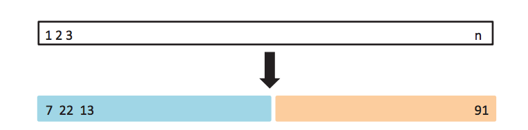

### Validation Set

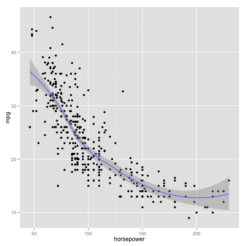

### Validation Set

Split into a single set, fit regression with different polynomial degrees.

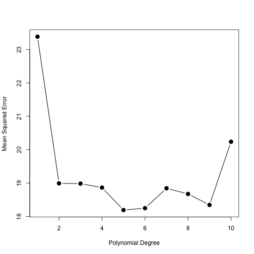

### Validation Set

Now replicate the same thing 10 times (with different validation and training sets).

- Only using 50% of data to train: this overestimates error
- Highly variable!: error rate is a random quantity, depends on observations in training and validation sets.

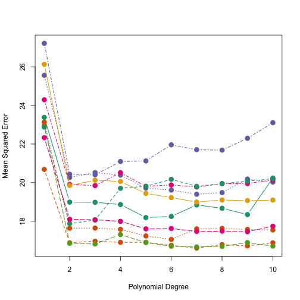

### Leave-one-out Cross-Validation

Procedure:  
For each observation \( i \) in data set:  
a. Train model on all but \( i \)-th observation  
b. Predict response for \( i \)-th observation  
c. Calculate prediction error

\[ CV_{(n)} = \frac{1}{n} \sum_i (y_i - \hat{y}_i)^2 \]

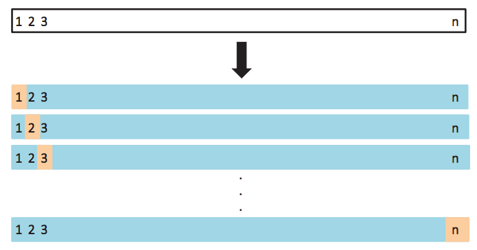

### Leave-one-out Cross-Validation

Advantages:

1. Uses \( n-1 \) observations to train model
2. There is no randomness, since error estimated on each sample

[figure not shown]

### Leave-one-out Cross-Validation

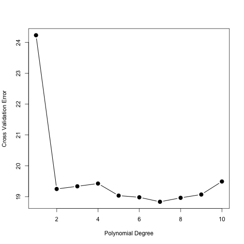

For linear models (and some non-linear models) there is a nice trick that allows one to compute (exactly or approximately) LOOCV from the full data model fit.

### k-fold Cross-Validation

Procedure:  
Partition observations randomly into \( k \) groups.

For each of the \( k \) groups of observations:

- Train model on observations in the other \( k-1 \) partitions
- Estimate test-set error (e.g., Mean Squared Error)

Compute average error across \( k \) folds

### k-fold Cross-Validation

\[ CV_{(k)} = \frac{1}{k} \sum_i MSE_i \]

where \( MSE_i \) is mean squared error estimated on the \( i \)-th fold

### k-fold Cross-Validation

Advantages:

- fewer models to fit
- less variance in the computed \( MSE_i \)

Disadvantages:

- Slight bias (over estimating usually) in error estimate

### k-fold Cross-Validation

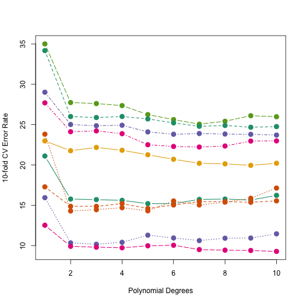

### Cross-Validation in Classification

- Each of these procedures can be used for classification as well.
- Substitute MSE with performance metric of choice. E.g., error rate, accuracy, TPR, FPR, AUROC
- Not all of these work with LOOCV (e.g. AUROC)

### Comparing Models

- Suppose you want to compare two classification models (logistic regression vs. knn) on the `Default` dataset.
- We can use Cross-Validation to determine if one model is better than the other.
- A t-test!

### Comparing Models

[output not shown]